# Exercice 3

**Question 1 : Créeons le vecteur Y contenant la variable que nous voulons modéliser et la matrice X contenant les 4 variables explicatives X1, . . ., X 4. Représentons Y en fonction de chacune des autres variables observe-t-on des liens linéaires ?**

Importation des données

```r
 data<-read.table("C:/Users/YODA ISMAEL/Desktop/Dossier Etudes/Dossiers Master/Semestre2/Régression linéaire/Devoir/Devoir_UT/data.txt",header = T,sep=" ",dec=".")
```

La variable dépendante Y

```r
Y<-data$Y
```

La matrice des variables exogènes X

```r
X1<-data$X1
X2<-data$X2
X3<-data$X3
X4<-data$X4
X<-cbind(X1,X2,X3,X4)
```

Réprésentation graphique de Y en fonction de X1

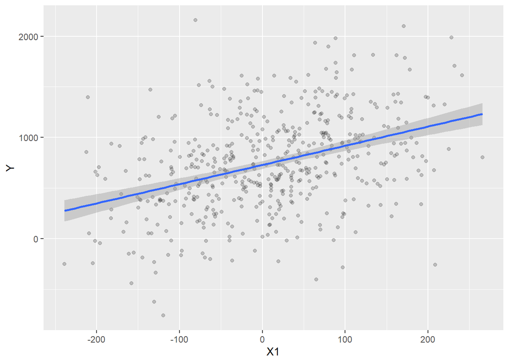

```r
library(ggplot2)
ggplot(data, aes(x = X1 , y = Y)) +
  geom_point(alpha = 0.2) +
  geom_smooth(method = "lm")
```

Representation graphique de Y en fonction de X2

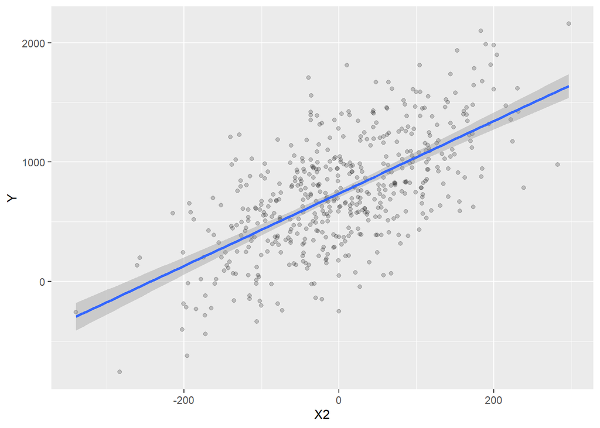

```r
ggplot(data, aes(x = X2 , y = Y)) +
  geom_point(alpha = 0.2) +
  geom_smooth(method = "lm")
```

Réprésentation graphique de Y en fonction de X3

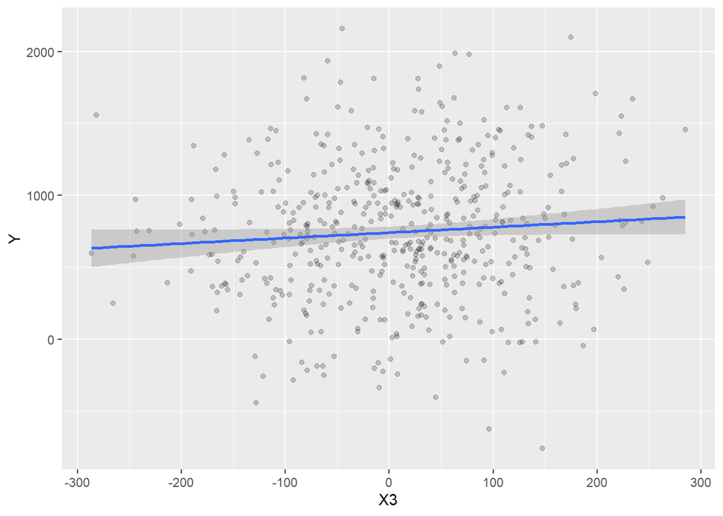

```r
ggplot(data, aes(x = X3 , y = Y)) +
  geom_point(alpha = 0.2) +
  geom_smooth(method = "lm")
```

Réprésentation graphique de Y en fonction de X4

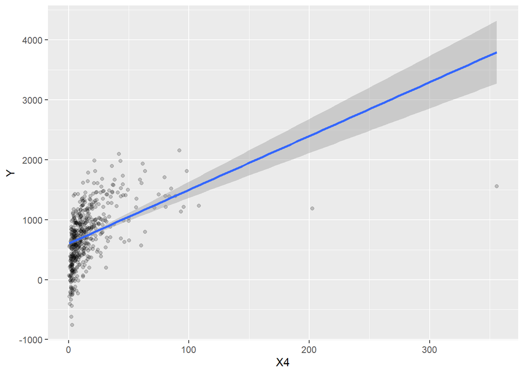

```r
ggplot(data, aes(x = X4 , y = Y)) +
  geom_point(alpha = 0.2) +
  geom_smooth(method = "lm")
```

Observations : On observe que les liens entre la variable à expliquer Y et les variables explicatives (X3,X4) ne semblent pas etre linéaires. Par contre il semble exister une relation linéaire entre Y et les variables (X1,X2).

**Question 2 : Réaliser la régression linéaire de Y sur l’ensemble des variables que vaut le R2 ? Certains coefficients sont-ils non significatifs? La régression paraît-elle acceptable ?**

```r
model<-lm(Y~X1+X2+X3+X4,data=data)
summary(model)
```

```
##
## Call:
## lm(formula = Y ~ X1 + X2 + X3 + X4, data = data)
##
## Residuals:
##     Min      1Q  Median      3Q     Max
## -1920.2  -113.0    47.3   162.6   309.9
##
## Coefficients:
##              Estimate Std. Error t value Pr(>|t|)
## (Intercept) 570.58133   11.61731  49.115   <2e-16 ***
## X1            2.10135    0.09920  21.182   <2e-16 ***
## X2            3.11306    0.09700  32.092   <2e-16 ***
## X3            0.23003    0.09659   2.381   0.0176 *
## X4            9.04170    0.39660  22.798   <2e-16 ***
## ---
## Signif. codes:  0 '***' 0.001 '**' 0.01 '*' 0.05 '.' 0.1 ' ' 1
##
## Residual standard error: 215 on 495 degrees of freedom
## Multiple R-squared:  0.7972, Adjusted R-squared:  0.7956
## F-statistic: 486.5 on 4 and 495 DF,  p-value: < 2.2e-16
```

Le R_carré du modèle vaut 0,7972. Les coefficients X1,X2 et X4 sont significatifs au seuil de 1% et la variable X3 est significative au seuil de 5%. La régréssion parrait acceptable car le R_carré est proche de 1 et les paramètres estimées sont tous significatifs.

**Question3: Pour i allant de 1 à 4, réalisons la régression de Y sur les variables {Xj: j =1, . . . , 4, j # i} et représenter les résidus en fonction de Xi.Des liens linéaires plus nets apparaissent-ils ? Voit-on d’autres liens ?**

Régréssion entre Y et X1 et représentation des résidus en fonction de X1

```r
model1<-lm(Y~X1,data=data)
summary(model1)
```

```
##
## Call:
## lm(formula = Y ~ X1, data = data)
##
## Residuals:
##      Min       1Q   Median       3Q      Max
## -1382.02  -275.56   -24.33   280.13  1582.35
##
## Coefficients:
##             Estimate Std. Error t value Pr(>|t|)
## (Intercept) 728.8316    19.7028  36.991   <2e-16 ***
## X1            1.8959     0.2018   9.397   <2e-16 ***
## ---
## Signif. codes:  0 '***' 0.001 '**' 0.01 '*' 0.05 '.' 0.1 ' ' 1
##
## Residual standard error: 438.8 on 498 degrees of freedom
## Multiple R-squared:  0.1506, Adjusted R-squared:  0.1489
## F-statistic: 88.31 on 1 and 498 DF,  p-value: < 2.2e-16
```

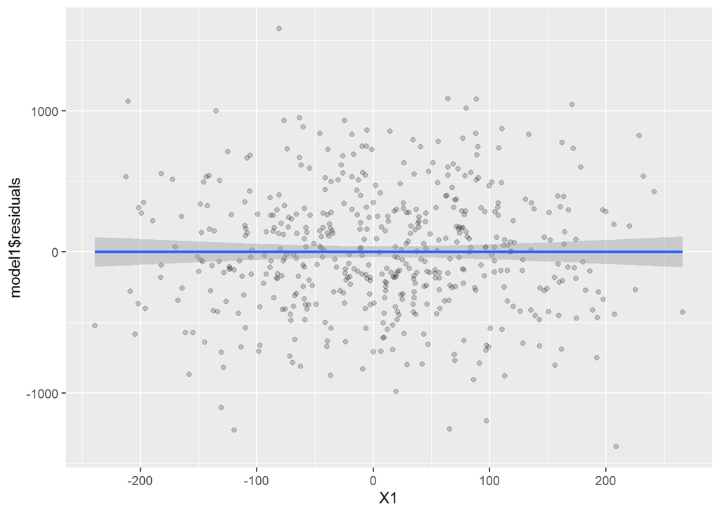

```r
ggplot(data, aes(x = X1 , y = model1$residuals)) +
  geom_point(alpha = 0.2) +
  geom_smooth(method = "lm")
```

Régréssion entre Y et X2 et représentation des résidus en fonction de X2

```r
model2<-lm(Y~X2,data=data)
summary(model2)
```

```
##
## Call:
## lm(formula = Y ~ X2, data = data)
##
## Residuals:
##     Min      1Q  Median      3Q     Max
## -985.25 -242.23  -19.32  251.02 1088.75
##
## Coefficients:
##             Estimate Std. Error t value Pr(>|t|)
## (Intercept)  736.906     16.439   44.83   <2e-16 ***
## X2             3.033      0.165   18.39   <2e-16 ***
## ---
## Signif. codes:  0 '***' 0.001 '**' 0.01 '*' 0.05 '.' 0.1 ' ' 1
##
## Residual standard error: 367.4 on 498 degrees of freedom
## Multiple R-squared:  0.4043, Adjusted R-squared:  0.4031
## F-statistic:   338 on 1 and 498 DF,  p-value: < 2.2e-16
```

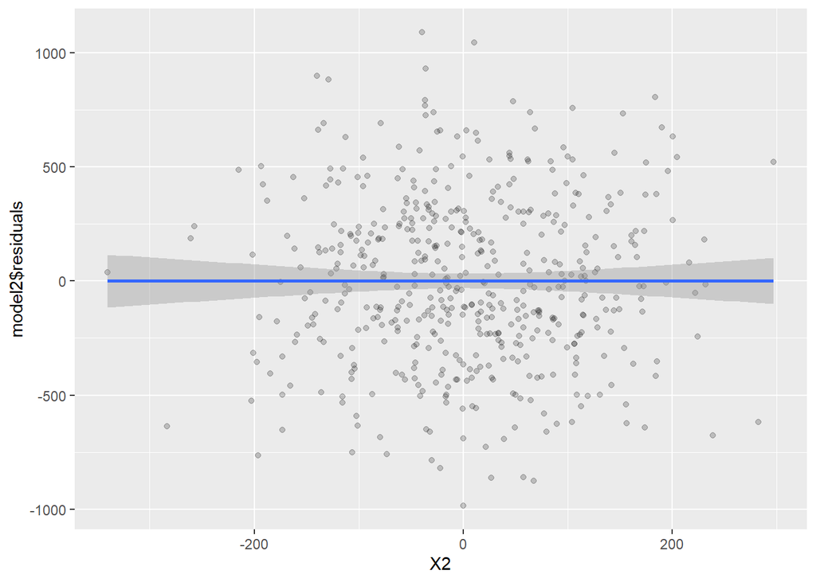

```r
ggplot(data, aes(x = X2, y = model2$residuals)) +
  geom_point(alpha = 0.2) +
  geom_smooth(method = "lm")
```

Régréssion entre Y et X3 et représentation des résidus en fonction de X3

```r
model3<-lm(Y~X3,data=data)
summary(model3)
```

```
##
## Call:
## lm(formula = Y ~ X3, data = data)
##
## Residuals:
##      Min       1Q   Median       3Q      Max
## -1556.98  -306.78   -10.81   299.81  1433.48
##
## Coefficients:
##             Estimate Std. Error t value Pr(>|t|)
## (Intercept) 741.8320    21.3257  34.786   <2e-16 ***
## X3            0.3781     0.2120   1.784   0.0751 .
## ---
## Signif. codes:  0 '***' 0.001 '**' 0.01 '*' 0.05 '.' 0.1 ' ' 1
##
## Residual standard error: 474.6 on 498 degrees of freedom
## Multiple R-squared:  0.006348,   Adjusted R-squared:  0.004353
## F-statistic: 3.182 on 1 and 498 DF,  p-value: 0.07508
```

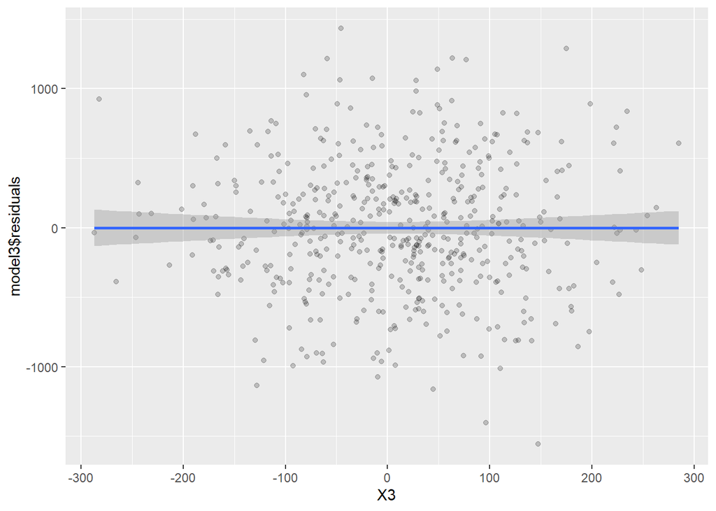

```r
ggplot(data, aes(x = X3 , y = model3$residuals)) +
  geom_point(alpha = 0.2) +
  geom_smooth(method = "lm")
```

Régréssion entre Y et X4 et représentation des résidus en fonction de X4

```r
model4<-lm(Y~X4,data=data)
summary(model4)
```

```
##
## Call:
## lm(formula = Y ~ X4, data = data)
##
## Residuals:
##      Min       1Q   Median       3Q      Max
## -2237.91  -271.92    15.21   268.69  1192.21
##
## Coefficients:
##             Estimate Std. Error t value Pr(>|t|)
## (Intercept) 601.2864    22.7027   26.48   <2e-16 ***
## X4            8.9775     0.7804   11.50   <2e-16 ***
## ---
## Signif. codes:  0 '***' 0.001 '**' 0.01 '*' 0.05 '.' 0.1 ' ' 1
##
## Residual standard error: 423.2 on 498 degrees of freedom
## Multiple R-squared:  0.2099, Adjusted R-squared:  0.2084
## F-statistic: 132.3 on 1 and 498 DF,  p-value: < 2.2e-16
```

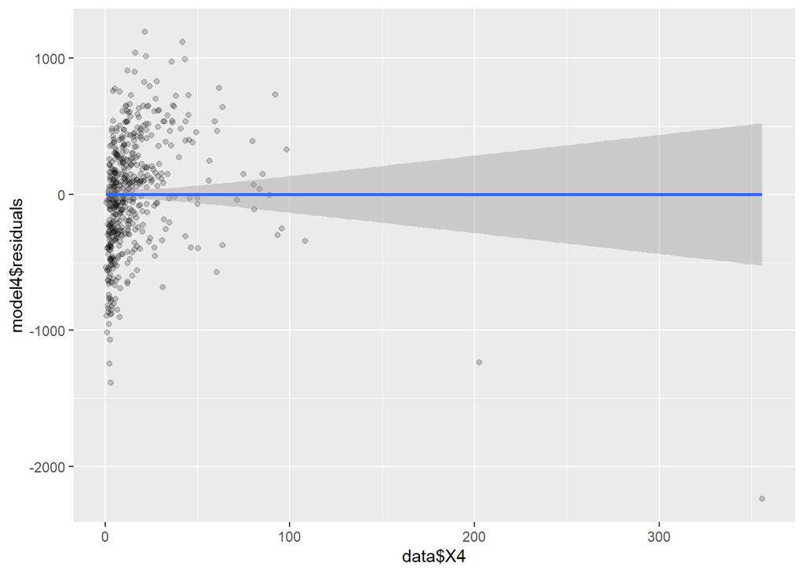

```r
ggplot(data,aes(x = data$X4 , y = model4$residuals)) +
  geom_point(alpha = 0.2) +
  geom_smooth(method = "lm")
```

Observations : Nous ne constatons pas l’apparition de liens linéaires plus net. Les liens linéaires entre la variable dépendante et les variables explicatives n’évoluent pas.

**Question 4: Construisons la matrice Z contenant les variables X1, X 2, X 3 et ln(X4). Faire la régression de Y sur les variables de Z et comparer les résultats à ceux obtenus lors de la première régression. Refaire la régression après avoir retiré l’une après l’autre les variables dont les coefficients ne sont pas significatifs (il faut en pratique éviter de retirer plusieurs variables en même temps : on retire d’abord la moins significative avant de refaire une régression). D’après les sorties, quel modèle est préférable ? Le retrait de X3 a-t-il fait augmenter le R2 ajusté ?**

Construction de la variable Z

```r
X1<-data$X1
X2<-data$X2
X3<-data$X3
lnX4<-log(data$X4)
Z<-cbind(X1,X2,X3,lnX4)
```

Estimation du modèle

```r
second_model_1<-lm(Y~X1+X2+X3+lnX4)
summary(second_model_1)
```

```
##
## Call:
## lm(formula = Y ~ X1 + X2 + X3 + lnX4)
##
## Residuals:
##      Min       1Q   Median       3Q      Max
## -119.106  -29.985   -0.311   28.064  132.717
##
## Coefficients:
##              Estimate Std. Error t value Pr(>|t|)
## (Intercept)  50.92217    4.53230  11.235   <2e-16 ***
## X1            2.01242    0.01938 103.840   <2e-16 ***
## X2            3.03279    0.01895 160.004   <2e-16 ***
## X3           -0.01731    0.01894  -0.914    0.361
## lnX4        298.97542    1.85056 161.560   <2e-16 ***
## ---
## Signif. codes:  0 '***' 0.001 '**' 0.01 '*' 0.05 '.' 0.1 ' ' 1
##
## Residual standard error: 42 on 495 degrees of freedom
## Multiple R-squared:  0.9923, Adjusted R-squared:  0.9922
## F-statistic: 1.587e+04 on 4 and 495 DF,  p-value: < 2.2e-16
```

Ce second modèle a un meilleure R_carré que le premier par contre,le paramètre X3 qui était significatif au premier modèle ne l’est plus au second modèle.

Retrais des variables non significatifs du modéle notamment X3

```r
second_model_2<-lm(Y~X1+X2+lnX4)
summary(second_model_2)
```

```
##
## Call:
## lm(formula = Y ~ X1 + X2 + lnX4)
##
## Residuals:
##      Min       1Q   Median       3Q      Max
## -120.840  -30.093   -1.178   27.594  133.917
##
## Coefficients:
##              Estimate Std. Error t value Pr(>|t|)
## (Intercept)  51.07129    4.52861   11.28   <2e-16 ***
## X1            2.01355    0.01934  104.12   <2e-16 ***
## X2            3.03141    0.01889  160.47   <2e-16 ***
## lnX4        298.82985    1.84338  162.11   <2e-16 ***
## ---
## Signif. codes:  0 '***' 0.001 '**' 0.01 '*' 0.05 '.' 0.1 ' ' 1
##
## Residual standard error: 42 on 496 degrees of freedom
## Multiple R-squared:  0.9923, Adjusted R-squared:  0.9922
## F-statistic: 2.117e+04 on 3 and 496 DF,  p-value: < 2.2e-16
```

D’après les sorties, le modèle sans la variable X3 est préferable car le retrait de la variable non significative (X3) ne change rien au modèle. Le R_carrée ajustée ne change pas.

**Question 5: Ajoutons la variable ln(X4) à la matrice X et déterminer par une méthode automatique, en utilisant le critère d’Akaike, quel est le meilleur modèle.**

```r
library(MASS)
X<-cbind(X1,X2,X3,X4,lnX4)
data<-as.data.frame(X)

modele=lm(Y~., data=data)
summary(modele)
```

```
##
## Call:
## lm(formula = Y ~ ., data = data)
##
## Residuals:
##      Min       1Q   Median       3Q      Max
## -119.027  -29.892   -0.277   28.074  132.488
##
## Coefficients:
##               Estimate Std. Error t value Pr(>|t|)
## (Intercept)  51.135616   5.179305   9.873   <2e-16 ***
## X1            2.012485   0.019413 103.666   <2e-16 ***
## X2            3.032836   0.018980 159.790   <2e-16 ***
## X3           -0.017177   0.019016  -0.903    0.367
## X4            0.009576   0.112088   0.085    0.932
## lnX4        298.810242   2.677571 111.598   <2e-16 ***
## ---
## Signif. codes:  0 '***' 0.001 '**' 0.01 '*' 0.05 '.' 0.1 ' ' 1
##
## Residual standard error: 42.04 on 494 degrees of freedom
## Multiple R-squared:  0.9923, Adjusted R-squared:  0.9922
## F-statistic: 1.267e+04 on 5 and 494 DF,  p-value: < 2.2e-16
```

```r
meilleur_modele=stepAIC(modele,~.,trace=TRUE,
                    direction=c("both"))
```

```
## Start:  AIC=3744.69
## Y ~ X1 + X2 + X3 + X4 + lnX4
##
##        Df Sum of Sq      RSS    AIC
## - X4    1        13   873269 3742.7
## - X3    1      1442   874699 3743.5
## <none>                873256 3744.7
## - X1    1  18997279 19870536 5305.1
## - lnX4  1  22015260 22888516 5375.8
## - X2    1  45134791 46008047 5724.9
##
## Step:  AIC=3742.7
## Y ~ X1 + X2 + X3 + lnX4
##
##        Df Sum of Sq      RSS    AIC
## - X3    1      1473   874743 3741.5
## <none>                873269 3742.7
## + X4    1        13   873256 3744.7
## - X1    1  19022888 19896157 5303.7
## - X2    1  45165472 46038742 5723.2
## - lnX4  1  46047720 46920989 5732.7
##
## Step:  AIC=3741.54
## Y ~ X1 + X2 + lnX4
##
##        Df Sum of Sq      RSS    AIC
## <none>                874743 3741.5
## + X3    1      1473   873269 3742.7
## + X4    1        44   874699 3743.5
## - X1    1  19121083 19995826 5304.2
## - X2    1  45413547 46288290 5723.9
## - lnX4  1  46346265 47221008 5733.9
```

```r
summary(meilleur_modele)
```

```
##
## Call:
## lm(formula = Y ~ X1 + X2 + lnX4, data = data)
##
## Residuals:
##      Min       1Q   Median       3Q      Max
## -120.840  -30.093   -1.178   27.594  133.917
##
## Coefficients:
##              Estimate Std. Error t value Pr(>|t|)
## (Intercept)  51.07129    4.52861   11.28   <2e-16 ***
## X1            2.01355    0.01934  104.12   <2e-16 ***
## X2            3.03141    0.01889  160.47   <2e-16 ***
## lnX4        298.82985    1.84338  162.11   <2e-16 ***
## ---
## Signif. codes:  0 '***' 0.001 '**' 0.01 '*' 0.05 '.' 0.1 ' ' 1
##
## Residual standard error: 42 on 496 degrees of freedom
## Multiple R-squared:  0.9923, Adjusted R-squared:  0.9922
## F-statistic: 2.117e+04 on 3 and 496 DF,  p-value: < 2.2e-16
```

Le meilleure modèle est le modèle Y ~ X1 + X2 + lnX4

Testons la normalité des résidus.Nous allons utiliser le test de Shapiro-Wilk.

```r
modele_choisi<-lm(Y~X1+X2+X3+lnX4,data=data)
residus<-modele_choisi$residuals
shapiro.test(residus)
```

```
##
##  Shapiro-Wilk normality test
##
## data:  residus
## W = 0.99766, p-value = 0.7185
```

L’hypothèse nulle du test est : L’échantillon suit une loi normale.La p-value de notre test est superieure a 5% donc on ne peut pas rejetter l’hypothèse nulle. Les résidus du modèle suivent donc une loi normale.

**Question 7: Testons l’hypothèse d’homoscédasticité.**

Nous allons utilisé le test d’homoscédasticité de Breusch-Pagan. L’hypothèse nulle du test est: les résidus ont une variance constante(homoscédasticité).

```r
library(lmtest)
bptest(modele_choisi)
```

```
##
##  studentized Breusch-Pagan test
##
## data:  modele_choisi
## BP = 3.6556, df = 4, p-value = 0.4546
```

Les résultats du test montrent que la p-value du test est superieure à 5% donc on ne peut pas rejetter l’hypothèse nulle. Les résidus sont donc homoscédastiques.

Verifation graphique en répresentant le nuage de point y_chapeau avec les residus standardisées.

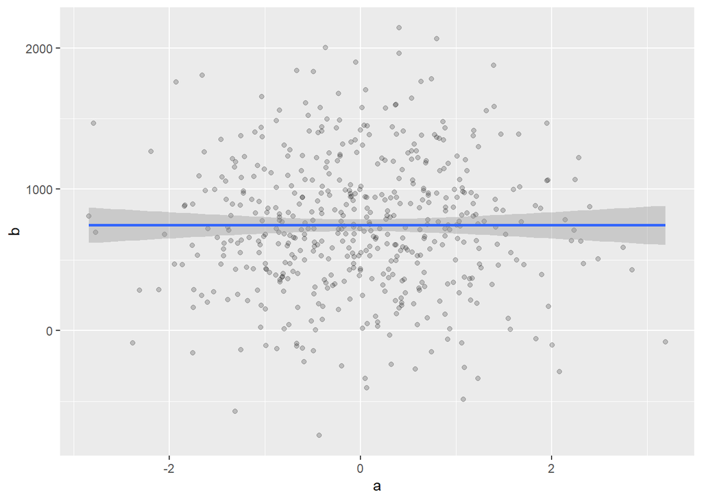

```r
a=rstandard(modele_choisi)
b=predict(modele_choisi)
c=cbind.data.frame(a,b)
ggplot(c,aes(x = a , y = b)) +
  geom_point(alpha = 0.2) +
  geom_smooth(method = "lm")
```

**Question 8: Donner un intervalle de confiance à 95%, puis à 99%, pour chacun des paramètres.Vérifier que l’ont obtient bien le même intervalle de confiance à 95% pour β1 en utilisant les formules du cours (il faut donc l’obtenir par calculs matriciels).**

Intervalle de confiance à 95%

```r
confint(modele_choisi,level = 0.95)
```

```
##                    2.5 %       97.5 %
## (Intercept)  42.01725415  59.82707774
## X1            1.97434561   2.05049979
## X2            2.99555181   3.07003397
## X3           -0.05451319   0.01990144
## lnX4        295.33949701 302.61133516
```

Intervalle de confiance à 99%

```r
confint(modele_choisi,level = 0.99)
```

```
##                    0.5 %       99.5 %
## (Intercept)  39.20256234  62.64176955
## X1            1.96231008   2.06253532
## X2            2.98378053   3.08180524
## X3           -0.06627379   0.03166204
## lnX4        294.19024457 303.76058760
```

```r
X<-cbind(rep(1,100),X1,X2,X3,lnX4)
A<-solve(t(X)%*%X)
Intervalle_B1<-c(2.01242270-qt(0.975,495)*sqrt(sum(modele_choisi$residuals^2)/495)*sqrt(A[1,1]),2.01242270+qt(0.975,495)*sqrt(sum(modele_choisi$residuals^2)/495)*sqrt(A[1,1]))
Intervalle_B1
```

```
## [1] -6.892489 10.917334
```

**Question 9: Donner une prévision et un intervalle de confiance (ou plutôt de pari) à 95% pour Y si X1 = X2 = X4 = 200. Retrouver par le calcul, avec les formules du cours,l’intervalle obtenu. Retrouver le résultat obtenu lorsque l’on choisit l’option interval=“confidence”..**

Prévision pour Y si X1 = X2 = X4 = 200

```r
predict(modele_choisi,data.frame(X1=200,X2=200,X3=200,X4=200,lnX4=log(200)))
```

```
##        1
## 2640.571
```

```r
x=rbind(1,200,200,200,log(200))
betas=rbind(50.92216595,2.01242270,3.03279289,-0.01730588,298.97541608)
sigma_chapeau<-sqrt(sum(modele_choisi$residuals^2)/495)

Intervalle_prev<-c(t(x)%*%betas-qt(0.975,495)*sigma_chapeau*
                    sqrt(1+t(x)%*%solve(t(X)%*%X))%*%x,
                   t(x)%*%betas+qt(0.975,495)*sigma_chapeau*
                     sqrt(1+t(x)%*%solve(t(X)%*%X))%*%x)
Intervalle_prev
```

```
## [1] -47395.55  52676.70
```

Retrouvons le résultat obtenu lorsque l’on choisit l’option interval = “confidence”.

```r
predict(modele_choisi,data.frame(X1=200,X2=200,X3=200,X4=200,lnX4=log(200)),interval="confidence")
```

```
##        fit      lwr    upr
## 1 2640.571 2623.942 2657.2
```